# Deep Generative Models for Novel GPCR Ligand Discovery

Dr. Mark James Thompson<sup>1</sup> (thok@zhaw.ch), Dr. Manuel Dömer (supervisor)<sup>2</sup>, Dr. Tomek Stepniewski (co-supervisor)<sup>3</sup>

1. Institute for Wealth and Asset Management, ZHAW

2. Programme [Director BSc. Data Science](https://manuel-doemer.ch/index.html), ZHAW

3. Senior Scientist Computational Chemistry, [InterAx AG](https://interaxbiotech.com/interax-homepage/about-us/)

# **Generative AI** can help find new drugs to combat multiple sclerosis.

*A conditional-RNN helps find novel inverse agonist ligands for ACKR3, a GPCR involved in MS pathology*

## Abstract

In this project, we use a conditional recurrent neural network models to generate novel ligands that may bind, and hopefully turn off that receptor.

## Methods

1. Gather relevant molecules:
- ZINC clinical
- ChEMBL GPCR ligands
- GLASS ACKR3 ligands
- InterAx ACKR3 ligands
1. Use *gnina* to predict ACKR3 binding scores of molecules
2. Integrate the molecules (SMILES) and scores with KNIME;
3. Develop an RNN for SMILES using:
   - 3 LSTM layers
   - 20% dropout
   - conditioning on binding score
   - 512 nodes
   - optimizing w/ sparse-cross entropy
4. Simulate the ligands in Boltz-2.

## Evaluation

Is there a best RNN model that works with conditioning in our experimental setup? Yes, but its not clear because of different training datasets.

We ran a comparison of RNN models experiments with different amounts of nodes and layers. We found that complicated models, like the 3 layer dropout model is not necessarily better than simpler architectures.

## Results

In conclusion, in our research we show:

- *gnina* can predict binding that accords with empirical assays;
- Conditioning on a binding score is useful for enriching an RNN;
- Boltz-2 is becoming a possible substitute for MD.

A conditional generative RNN is a useful model for the generating molecules. Our framework for developing novel molecules is relatively simple and can applied to other parameters or ligands.

This study was brought to you by [ZHAW](https://www.zhaw.ch/en/lsfm/studies/master/applied-computational-life-sciences), Applied Computational Life Sciences and [InterAx AG](https://interaxbiotech.com)

# Extra Tables & Figures

## *gnina* can predict

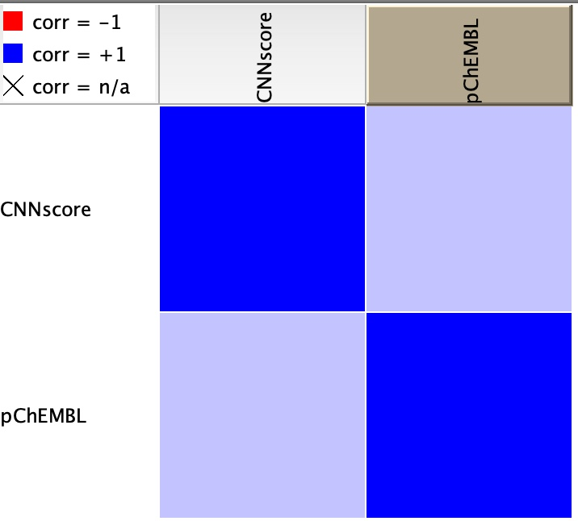

Figure 1: KNIME reports a modest but statistcaly significant correlation of 0.236 between *gnina* binding score the binding affinity as measure interms of pChEMBL (p-value=0.000 on 575 degrees of freedom)

## Bigger isn’t Better

The Segler model has many more hidden nodes (1024) and complicated structure (3-layers), but even smaller models with 512 nodes can generate similar results. Bigger is not necessarily better when it comes to conditional RNN models.

Table 1: Overview of RNN attributes.

| Model | Validity (%) | Uniqueness (%) | Novelty (%) | Avg. QED | Avg. SA | Avg. SlogP | Internal Diversity |
| --- | --- | --- | --- | --- | --- | --- | --- |
| Real | 100.0 | 100 | 0.0 | 0.646 | 3.07 | 3.15 | 0.877 |
| Polykovskiy | 64.6 | 100 | 100.0 | 0.772 | 2.06 | 3.21 | 0.798 |
| Bjerrum | 72.7 | 100 | 100.0 | 0.782 | 2.42 | 3.52 | 0.838 |
| Gupta | 75.0 | 100 | 100.0 | 0.801 | 2.28 | 3.60 | 0.826 |
| Kostias | 2.1 | 100 | 100.0 | 0.061 | 2.91 | 6.38 | NA |
| Segler | 67.3 | 100 | 100.0 | 0.802 | 2.16 | 3.31 | 0.821 |
| Olivecrona | 0.6 | 100 | 100.0 | 0.095 | 3.38 | 13.00 | 0.715 |
| XuGrisini | 2.7 | 100 | 100.0 | 0.092 | 2.93 | 19.90 | 0.539 |
| 64h512_2m | 79.2 | 100 | 100.0 | 0.774 | 2.26 | 3.33 | 0.832 |
| 64h512_4m | 75.5 | 100 | 99.8 | 0.750 | 2.31 | 3.61 | 0.836 |
| 64h512_8m | 78.6 | 100 | 100.0 | 0.776 | 2.25 | 3.19 | 0.833 |
| 64h1024_4m | 77.1 | 100 | 100.0 | 0.790 | 1.99 | 3.33 | 0.789 |

## Raising Expectations

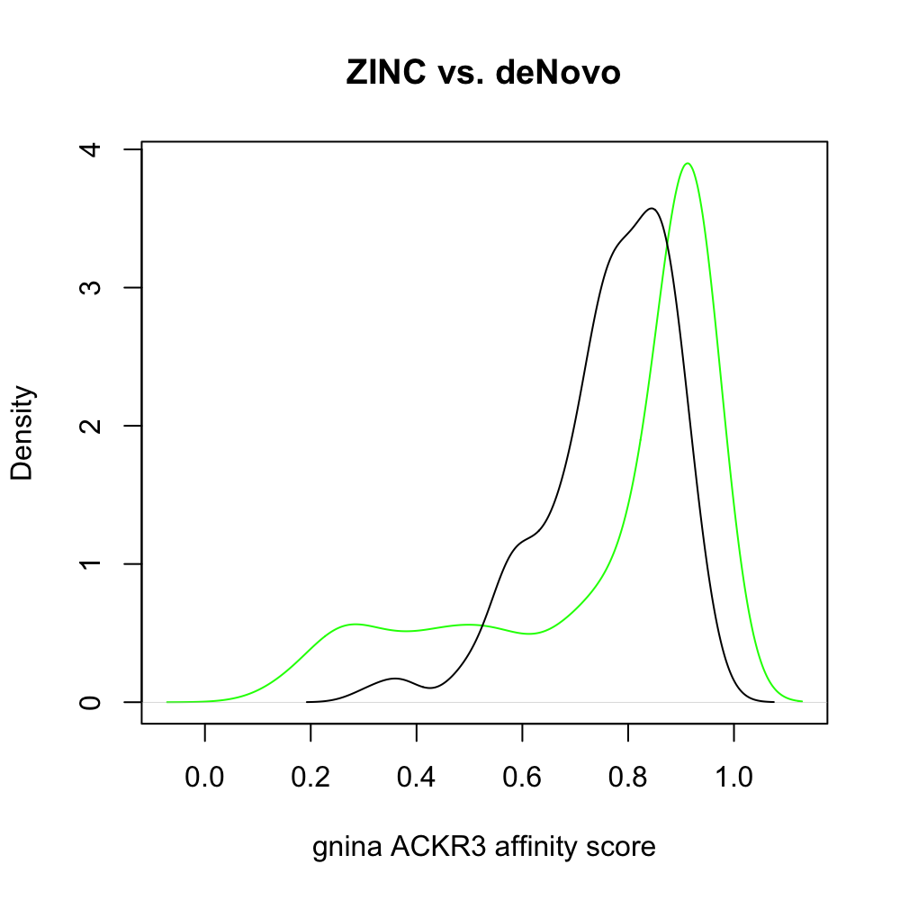

Figure 2: Generating molecules conditioning on binding score, shifts the distribution of those molecules towards higher scores with also some unusable candidates.

## Hitting the Target

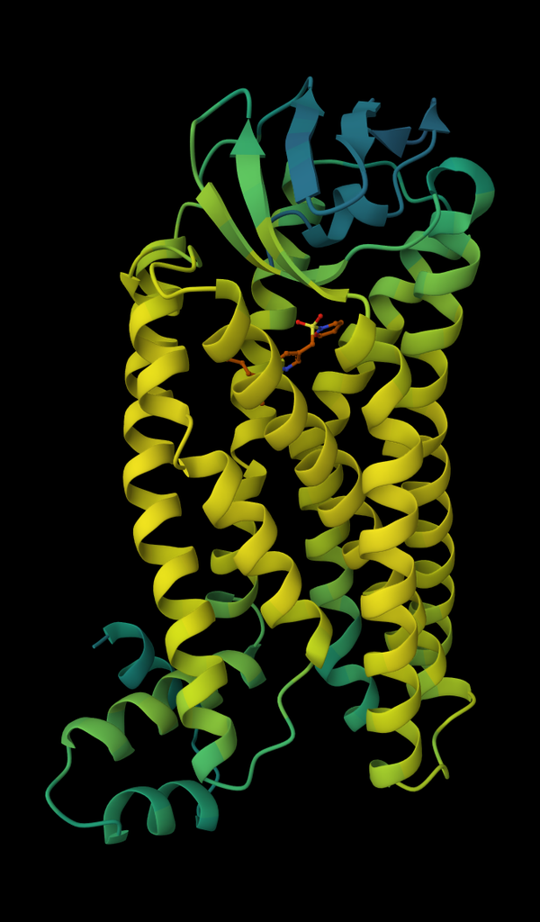

Figure 3: After a simulation with Boltz-2, candidate A ligand appears to be seated where a known inverse agonist sits

# Key References

Pouzol, Laetitia. 2022. “Pre-Clinical Development of ACT-1004-1239, a Potent and Selective CXCR7/ACKR3 Antagonist in Multiple Sclerosis Treatment.” *PhD Thesis*. Université Paris-Caclay.